# Solving the n-Queens Problem using Local Search

Student Name: [Zahra Hoobakht]

I understand that my submission needs to be my own work: [ZH]

## Instructions

Total Points: Undergrads 100 + 5 bonus / Graduate students 110

Complete this notebook. Use the provided notebook cells and insert additional code and markdown cells as needed. Submit the completely rendered notebook as a HTML file.

## The n-Queens Problem

- **Goal:** Find an arrangement of $n$ queens on a $n \times n$ chess board so that no queen is on the same row, column or diagonal as any other queen.
- **State space:** An arrangement of the queens on the board. We restrict the state space to arrangements where there is only a single queen per column. We represent a state as an integer vector $\mathbf{q} = \{q_1, q_2, \dots, q_n\}$, each number representing the row positions of the queens from left to right. We will call a state a "board."
- **Objective function:** The number of pairwise conflicts (i.e., two queens in the same row/column/diagonal). The optimization problem is to find the optimal arrangement $\mathbf{q}^*$ of $n$ queens on the board can be written as:

  > minimize: $\mathrm{conflicts}(\mathbf{q})$

  > subject to: $\mathbf{q} \ \text{contains only one queen per column}$

  Note: the constraint (subject to) is enforced by the definition of the state space.
- **Local improvement move:** Move one queen to a different row in its column.
- **Termination:** For this problem there is always an arrangement $\mathbf{q}^*$ with $\mathrm{conflicts}(\mathbf{q}^*) = 0$, however, the local improvement moves might end up in a local minimum.

## Helper functions

```python
import numpy as np
import matplotlib.pyplot as plt
from matplotlib import colors

np.random.seed(1234)


def random_board(n):
    """Creates a random board of size n x n. Note that only a single queen is placed in each column!"""

    return(np.random.randint(0,n, size = n))

def comb2(n): return n*(n-1)//2 # this is n choose 2 equivalent to math.comb(n, 2); // is int division

def conflicts(board):
    """Calculate the number of conflicts, i.e., the objective function."""

    n = len(board)

    horizontal_cnt = [0] * n
    diagonal1_cnt = [0] * 2 * n
    diagonal2_cnt = [0] * 2 * n

    for i in range(n):
        horizontal_cnt[board[i]] += 1
        diagonal1_cnt[i + board[i]] += 1
        diagonal2_cnt[i - board[i] + n] += 1

    return sum(map(comb2, horizontal_cnt + diagonal1_cnt + diagonal2_cnt))

# decrease the font size to fit larger boards
def show_board(board, cols = ['white', 'gray'], fontsize = 48):
    """display the board"""

    n = len(board)

    # create chess board display
    display = np.zeros([n,n])
    for i in range(n):
        for j in range(n):
            if (((i+j) % 2) != 0):
                display[i,j] = 1

    cmap = colors.ListedColormap(cols)
    fig, ax = plt.subplots()
    ax.imshow(display, cmap = cmap,
              norm = colors.BoundaryNorm(range(len(cols)+1), cmap.N))
    ax.set_xticks([])
    ax.set_yticks([])

    # place queens. Note: Unicode u265B is a black queen
    for j in range(n):
        plt.text(j, board[j], u"\u265B", fontsize = fontsize,
                 horizontalalignment = 'center',
                 verticalalignment = 'center')

    print(f"Board with {conflicts(board)} conflicts.")
    plt.show()
```

## Create a board

```
Board with 4 conflicts.
```

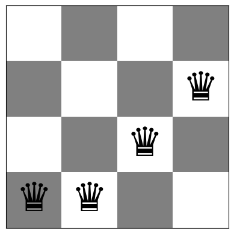

```
Queens (left to right) are at rows: [3 3 2 1]
Number of conflicts: 4
```

```python
board = random_board(4)

show_board(board)
print(f"Queens (left to right) are at rows: {board}")
print(f"Number of conflicts: {conflicts(board)}")
```

A board $4 \times 4$ with no conflicts:

```python
board1 = [1,3,0,2]
show_board(board1)
```

```
Board with 0 conflicts.
```

# Tasks

## General [10 Points]

1. Make sure that you use the latest version of this notebook. Sync your forked repository and pull the latest revision.
2. Your implementation can use libraries like math, numpy, scipy, but not libraries that implement intelligent agents or complete search algorithms. Try to keep the code simple! In this course, we want to learn about the algorithms and we often do not need to use object-oriented design.
3. You notebook needs to be formatted professionally.
   - Add additional markdown blocks for your description, comments in the code, add tables and use mathplotlib to produce charts where appropriate
   - Do not show debugging output or include an excessive amount of output.
   - Check that your PDF file is readable. For example, long lines are cut off in the PDF file. You don't have control over page breaks, so do not worry about these.
4. Document your code. Add a short discussion of how your implementation works and your design choices.

## Task 1: Steepest-ascend Hill Climbing Search [30 Points]

Calculate the objective function for all local moves (see definition of local moves above) and always choose the best among all local moves. If there are no local moves that improve the objective, then you have reached a local optimum.

```python
def steepest_ascent_hill_climb(board):
    """Performs steepest-ascent hill climbing to find a solution."""
    n = len(board)
    current_conflicts = conflicts(board)

    while True:
        best_move = None
        best_conflict = current_conflicts

        # Explore all possible moves
        for col in range(n):
            original_row = board[col]
            for row in range(n):
                if row == original_row:
                    continue

                # Create a new board with the queen moved to (col, row)
                board[col] = row
                new_conflicts = conflicts(board)

                # Check if this is the best move so far
                if new_conflicts < best_conflict:
                    best_conflict = new_conflicts
                    best_move = (col, row)

            # Reset column to original row for next evaluation
            board[col] = original_row

        # If we found an improving move, make it
        if best_move:
            col, row = best_move
            board[col] = row
            current_conflicts = best_conflict
        else:
            # No better moves found; local optimum reached
            break

    return board,current_conflicts
[board_res,board_conflicts]=steepest_ascent_hill_climb(board)
print('number of conflicts are ', board_conflicts)
show_board(board_res)
```

```
number of conflicts are  1
Board with 1 conflicts.
```

```python
import time
def result(n,method):
    time_ave=[]
    conf_ave=[]
    conf_fin=0
    for i in range(1,100):
        board1=random_board(n)
        start_time=time.time()
        [board_res1,board_conflicts1]=method(board1)
        run_time=time.time()-start_time
        conf_ave.append(board_conflicts1)
        time_ave.append(run_time)
    for i in range(len(conf_ave)):
        if conf_ave[i]==0:
            conf_fin+=1

    return np.average(time_ave),np.average(conf_ave),conf_fin
```

```python
[time_ave_steep4,conf_ave_steep4,conf_fin_steep4]=result(4,steepest_ascent_hill_climb)
print(time_ave_steep4,conf_ave_steep4,conf_fin_steep4)
```

```
0.0007045341260505445 0.5353535353535354 48
```

```python
board1 = random_board(8)
[board_res1,board_conflicts1]=steepest_ascent_hill_climb(board1)
show_board(steepest_ascent_hill_climb(board1)[0])
[time_ave_steep8,conf_ave_steep8,conf_fin_steep8]=result(8,steepest_ascent_hill_climb)
```

```
Board with 1 conflicts.
```

```python
print(time_ave_steep8,conf_ave_steep8,conf_fin_steep8)
```

```
0.003929017770169962 1.0808080808080809 19
```

```python
[time_ave_steep12,conf_ave_steep12,conf_fin_steep12]=result(12,steepest_ascent_hill_climb)
print(time_ave_steep12,conf_ave_steep12,conf_fin_steep12)
```

```
0.014244886359783134 1.7777777777777777 6
```

```python
[time_ave_steep20,conf_ave_steep20,conf_fin_steep20]=result(20,steepest_ascent_hill_climb)
print(time_ave_steep20,conf_ave_steep20,conf_fin_steep20)
```

```
0.11449844668609928 2.323232323232323 3
```

The code starts by counting the initial conflicts on the board and then repeatedly evaluates all possible moves for each queen to find the position that reduces conflicts the most. If a better position is found, it moves the queen; otherwise, it concludes that a local optimum has been reached. The algorithm continues until no further improvements can be made, returning the final board configuration and the number of remaining conflicts.

## Task 2: Stochastic Hill Climbing 1 [10 Points]

Chooses randomly from among all uphill moves till you have reached a local optimum.

```python
def stochastic_hill_climb(board):

    n = len(board)
    current_conflicts = conflicts(board)

    while True:
        # Collect all uphill moves (moves that reduce conflicts)
        improving_moves = []

        for col in range(n):
            original_row = board[col]
            for row in range(n):
                if row == original_row:
                    continue

                # Try moving the queen to (col, row)
                board[col] = row
                new_conflicts = conflicts(board)

                # Check if this move is an uphill move
                if new_conflicts < current_conflicts:
                    improving_moves.append((col, row, new_conflicts))

            # Reset to the original row after trying all moves in this column
            board[col] = original_row

        # If no improving moves found, we have reached a local optimum
        if not improving_moves:
            break

        # Choose a random move from the uphill moves
        col, row, best_conflict = improving_moves[np.random.randint(len(improving_moves))]
        board[col] = row
        current_conflicts = best_conflict

    return board,current_conflicts
show_board(stochastic_hill_climb(board)[0])
```

```
Board with 1 conflicts.
```

```python
[time_ave_stoch4,conf_ave_stoch4,conf_fin_stoch4]=result(4,stochastic_hill_climb)
print(time_ave_stoch4,conf_ave_stoch4,conf_fin_stoch4)
```

```
0.00027197780031146425 0.8585858585858586 32
```

```python
show_board(stochastic_hill_climb(board1)[0])
```

```
Board with 1 conflicts.
```

```python
[time_ave_stoch8,conf_ave_stoch8,conf_fin_stoch8]=result(8,stochastic_hill_climb)
print(time_ave_stoch8,conf_ave_stoch8,conf_fin_stoch8)
```

```
0.004735845507997455 1.3636363636363635 15
```

```python
[time_ave_stoch12,conf_ave_stoch12,conf_fin_stoch12]=result(12,stochastic_hill_climb)
print(time_ave_stoch12,conf_ave_stoch12,conf_fin_stoch12)
```

```
0.023030719371757123 1.797979797979798 3
```

```python
[time_ave_stoch20,conf_ave_stoch20,conf_fin_stoch20]=result(20,stochastic_hill_climb)
print(time_ave_stoch20,conf_ave_stoch20,conf_fin_stoch20)
```

```
0.18626732055586998 2.3838383838383836 0
```

The code initializes by counting the current conflicts and then repeatedly collects all possible moves that reduce conflicts. If no improving moves are found, the algorithm stops, indicating a local optimum. If there are valid moves, it randomly selects one to execute, updating the board and the count of conflicts until no further improvements can be made.

## Task 3: Stochastic Hill Climbing 2 [20 Points]

A popular version of stochastic hill climbing generates only a single random local neighbor at a time and accept it if it has a better objective function value than the current state. This is very efficient if each state has many possible successor states. This method is called "First-choice hill climbing" in the textbook.

**Notes:**

- Detecting local optima is tricky! You can, for example, stop if you were not able to improve the objective function during the last $x$ tries.

```python
def first_choice_hill_climb(board, max_attempts=100):
    """Performs first-choice hill climbing to find a solution."""
    n = len(board)
    current_conflicts = conflicts(board)
    no_improvement_count = 0

    while no_improvement_count < max_attempts:
        # Generate a random neighboring move
        col = np.random.randint(n)        # Randomly select a column
        row = np.random.randint(n)        # Randomly select a row
        while row == board[col]:          # Ensure it's a different row
            row = np.random.randint(n)

        # Move queen in the selected column to the new row
        original_row = board[col]
        board[col] = row
        new_conflicts = conflicts(board)

        if new_conflicts < current_conflicts:
            # Accept the move if it improves the objective
            current_conflicts = new_conflicts
            no_improvement_count = 0  # Reset counter

        else:
            # Reject the move and reset to the original position
            board[col] = original_row
            no_improvement_count += 1  # Increment the failure count

    return board,current_conflicts
show_board(first_choice_hill_climb(board)[0])
```

```
Board with 1 conflicts.
```

```python
[time_ave_first4,conf_ave_first4,conf_fin_first4]=result(4,first_choice_hill_climb)
print(time_ave_first4,conf_ave_first4,conf_fin_first4)
```

```
0.0016118468660296817 0.7878787878787878 33
```

```python
show_board(first_choice_hill_climb(board1)[0])
```

```
Board with 1 conflicts.
```

```python
[time_ave_first8,conf_ave_first8,conf_fin_first8]=result(8,first_choice_hill_climb)
print(time_ave_first8,conf_ave_first8,conf_fin_first8)
```

```
0.0027707249227196277 1.4646464646464648 8
```

```python
show_board(first_choice_hill_climb(board1)[0])
```

```
Board with 1 conflicts.
```

```python
[time_ave_first12,conf_ave_first12,conf_fin_first12]=result(12,first_choice_hill_climb)
print(time_ave_first12,conf_ave_first12,conf_fin_first12)
```

```
0.004906432797210385 2.393939393939394 0
```

```python
[time_ave_first20,conf_ave_first20,conf_fin_first20]=result(20,first_choice_hill_climb)
print(time_ave_first20,conf_ave_first20,conf_fin_first20)
```

```
0.008981047254620176 4.08080808080808 0
```

The code begins with counting the current conflicts and then enters a loop that runs until a specified number of unsuccessful attempts (max_attempts) is reached. In each iteration, it randomly selects a column and a new row for the queen in that column, ensuring it does not move to its original row. If this move reduces the number of conflicts, the move is accepted; otherwise, it is reverted, and a failure counter is incremented. The process continues until a maximum number of attempts is made, then returns the final board configuration and the number of remaining conflicts.

## Task 4: Hill Climbing Search with Random Restarts [10 Points]

Hill climbing will often end up in local optima. Restart the each of the three hill climbing algorithm up to 100 times with a random board to find a better (hopefully optimal) solution. Note that restart just means to run the algorithm several times starting with a new random board.

```python
def random_restart_steepest_ascent(n, max_restarts=100):
    best_board = None
    best_conflict = float('inf')

    for _ in range(max_restarts):
        board = random_board(n)
        solution = steepest_ascent_hill_climb(board)[0]
        solution_conflicts = conflicts(solution)

        if solution_conflicts < best_conflict:
            best_board = solution
            best_conflict = solution_conflicts

        if best_conflict == 0:  # Found an optimal solution
            break

    return best_board,best_conflict
```

```python
[best_board,best_conflict]=random_restart_steepest_ascent(4, max_restarts=100)
show_board(best_board)
```

```
Board with 0 conflicts.
```

```
Board with 0 conflicts.
```

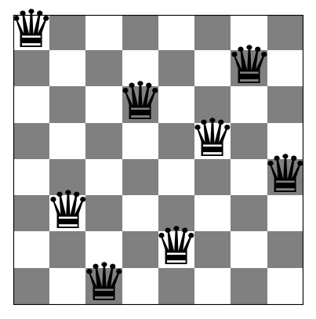

```python
[best_board,best_conflict]=random_restart_steepest_ascent(8, max_restarts=100)
show_board(best_board)
```

```python
def random_restart_stochastic_hill_climb(n, max_restarts=100):
    best_board = None
    best_conflict = float('inf')

    for _ in range(max_restarts):
        board = random_board(n)
        solution = stochastic_hill_climb(board)[0]
        solution_conflicts = conflicts(solution)

        if solution_conflicts < best_conflict:
            best_board = solution
            best_conflict = solution_conflicts

        if best_conflict == 0:  # Found an optimal solution
            break

    return best_board,best_conflict
```

```python
[best_board,best_conflict]=random_restart_stochastic_hill_climb(4, max_restarts=100)
show_board(best_board)
```

```
Board with 0 conflicts.
```

```
Board with 0 conflicts.
```

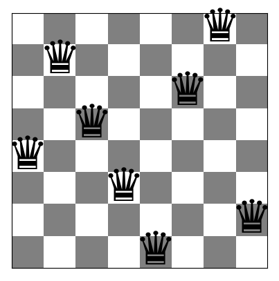

```python
[best_board,best_conflict]=random_restart_stochastic_hill_climb(8, max_restarts=100)
show_board(best_board)
```

```python
def random_restart_first_choice_hill_climb(n, max_restarts=100, max_attempts=100):
    best_board = None
    best_conflict = float('inf')

    for _ in range(max_restarts):
        board = random_board(n)
        solution = first_choice_hill_climb(board, max_attempts=max_attempts)[0]
        solution_conflicts = conflicts(solution)

        if solution_conflicts < best_conflict:
            best_board = solution
            best_conflict = solution_conflicts

        if best_conflict == 0:  # Found an optimal solution
            break

    return best_board,best_conflict
```

```
Board with 0 conflicts.
```

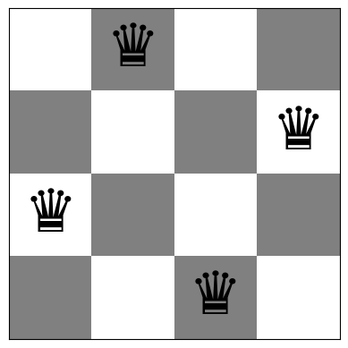

```python
[best_board,best_conflict]=random_restart_first_choice_hill_climb(4, max_restarts=100, max_attempts=100)
show_board(best_board)
```

```
Board with 0 conflicts.
```

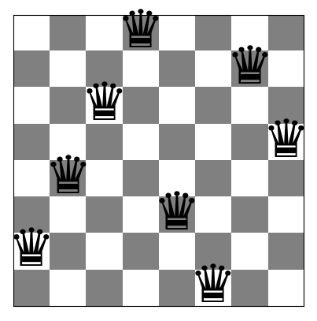

```python
[best_board,best_conflict]=random_restart_first_choice_hill_climb(8, max_restarts=100, max_attempts=100)
show_board(best_board)
```

## Task 5: Simulated Annealing [10 Points]

Simulated annealing is a form of stochastic hill climbing that avoid local optima by also allowing downhill moves with a probability proportional to a temperature. The temperature is decreased in every iteration following an annealing schedule. You have to experiment with the annealing schedule (Google to find guidance on this).

1. Implement simulated annealing for the n-Queens problem.
2. Compare the performance with the previous algorithms.
3. Discuss your choice of annealing schedule.

```python
import math
def simulated_annealing(board, initial_temp=100, cooling_rate=0.95, max_steps=1000):
    """Simulated annealing for n-Queens problem with adjustable annealing schedule."""
    n=len(board)
    current_conflicts = conflicts(board)
    temperature = initial_temp

    for step in range(max_steps):
        if current_conflicts == 0:
            break  # Optimal solution found

        # Choose a random neighbor
        col = np.random.randint(n)
        row = np.random.randint(n)
        while row == board[col]:  # Ensure it's a different row
            row = np.random.randint(n)

        # Calculate conflict of new state
        original_row = board[col]
        board[col] = row
        new_conflicts = conflicts(board)

        # Calculate change in objective function
        delta_e = new_conflicts - current_conflicts

        # Decide whether to accept the move
        if delta_e < 0 or np.random.rand() < math.exp(-delta_e / temperature):
            # Accept the move
            current_conflicts = new_conflicts
        else:
            # Revert the move
            board[col] = original_row

        # Cool down the temperature
        temperature *= cooling_rate

    return board, current_conflicts
```

```python
[time_ave_SA4,conf_ave_SA4,conf_fin_SA4]=result(4,simulated_annealing)
print(time_ave_SA4,conf_ave_SA4,conf_fin_SA4)
```

```
0.0014707921731351601 0.0 99
```

```
Board with 0 conflicts.
```

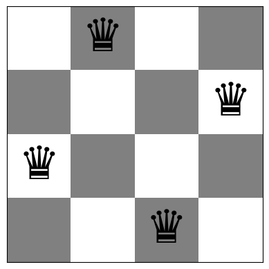

```python
show_board(simulated_annealing(board, initial_temp=100, cooling_rate=0.95, max_steps=1000)[0])
```

```python
[time_ave_SA8,conf_ave_SA8,conf_fin_SA8]=result(8,simulated_annealing)
print(time_ave_SA8,conf_ave_SA8,conf_fin_SA8)
```

```
0.012705275506684275 0.3434343434343434 65
```

```
Board with 0 conflicts.
```

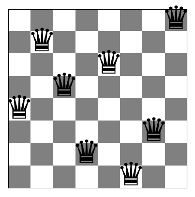

```python
show_board(simulated_annealing(board1, initial_temp=100, cooling_rate=0.95, max_steps=1000)[0])
```

```python
[time_ave_SA12,conf_ave_SA12,conf_fin_SA12]=result(12,simulated_annealing)
print(time_ave_SA12,conf_ave_SA12,conf_fin_SA12)
```

```
0.02175994352860884 0.7373737373737373 30
```

```python
[time_ave_SA20,conf_ave_SA20,conf_fin_SA20]=result(20,simulated_annealing)
print(time_ave_SA20,conf_ave_SA20,conf_fin_SA20)
```

```
0.03876529558740481 1.4242424242424243 11
```

It starts by generating a random board configuration and calculating the initial number of conflicts. The algorithm then iteratively selects random moves for the queens and evaluates whether these moves reduce conflicts. It accepts moves that improve the board and may also accept worse moves based on a probability that decreases over time, simulating a cooling process. In other words, at high temperatures, worse moves are more likely to be accepted, encouraging exploration. As the temperature cools, the acceptance of worse moves becomes less likely, allowing the algorithm to focus on refining the best solutions found.This approach helps the algorithm escape local optima as it searches for a configuration with no conflicts, eventually returning the final board state and the number of remaining conflicts.

A higher initial temperature (100 degree) allows the algorithm to accept more uphill moves early in the process, facilitating exploration. A slower cooling rate (e.g., a cooling factor close to 0.95) allows for more extensive exploration in the beginning, while a faster cooling rate can lead to premature convergence.

## Task 6: Compare Performance [10 Points]

Compare the algorithm using runtime and objective function values. Use boards of size 4 and 8 to explore how the different algorithms perform. Make sure that you run the algorithms for each board size several times (at least 100 times) with different starting boards and report averages.

Complete the following table

```python
import pandas as pd

# Create a dictionary with the data for each algorithm (initialize as empty or zero)
data = {
    'Algorithm': ['Steepest asc. HC', 'Stochastic HC 1', 'Stochastic HC 2', 'Simulated Annealing','Steepest asc. HC','Stochastic HC 1','Stochastic HC 2','Simulated Annealing','Steepest asc. HC', 'Stochastic HC 1', 'Stochastic HC 2', 'Simulated Annealing','Steepest asc. HC', 'Stochastic HC 1', 'Stochastic HC 2', 'Simulated Annealing'],
    'Board size': [4,4, 4, 4,8,8,8,8,12,12,12,12,20,20,20,20],
    'Avg. Run time': [time_ave_steep4,time_ave_stoch4,time_ave_first4,time_ave_SA4,time_ave_steep8,time_ave_stoch8,time_ave_first8,time_ave_SA8,time_ave_steep12,time_ave_stoch12,time_ave_first12,time_ave_SA12,time_ave_steep20,time_ave_stoch20,time_ave_first20,time_ave_SA20],
    'Avg. number of conflicts': [conf_ave_steep4,conf_ave_stoch4,conf_ave_first4,conf_ave_SA4,conf_ave_steep8,conf_ave_stoch8,conf_ave_first8,conf_ave_SA8,conf_ave_steep12,conf_ave_stoch12,conf_ave_first12,conf_ave_SA12,conf_ave_steep20,conf_ave_stoch20,conf_ave_first20,conf_ave_SA20],
    '% of runs ending in optimal solution': [conf_fin_steep4,conf_fin_stoch4,conf_fin_first4,conf_fin_SA4,conf_fin_steep8,conf_fin_stoch8,conf_fin_first8,conf_fin_SA8,conf_fin_steep12,conf_fin_stoch12,conf_fin_first12,conf_fin_SA12,conf_fin_steep20,conf_fin_stoch20,conf_fin_first20,conf_fin_SA20]
    }

# Create a DataFrame from the dictionary
df= pd.DataFrame(data)

# Display the DataFrame
df
```

|  | Algorithm | Board size | Avg. Run time | Avg. number of conflicts | % of runs ending in optimal solution |
| --- | --- | --- | --- | --- | --- |
| 0 | Steepest asc. HC | 4 | 0.000705 | 0.535354 | 48 |
| 1 | Stochastic HC 1 | 4 | 0.000272 | 0.858586 | 32 |
| 2 | Stochastic HC 2 | 4 | 0.001612 | 0.787879 | 33 |
| 3 | Simulated Annealing | 4 | 0.001471 | 0.000000 | 99 |
| 4 | Steepest asc. HC | 8 | 0.003929 | 1.080808 | 19 |
| 5 | Stochastic HC 1 | 8 | 0.004736 | 1.363636 | 15 |
| 6 | Stochastic HC 2 | 8 | 0.002771 | 1.464646 | 8 |
| 7 | Simulated Annealing | 8 | 0.012705 | 0.343434 | 65 |
| 8 | Steepest asc. HC | 12 | 0.014245 | 1.777778 | 6 |
| 9 | Stochastic HC 1 | 12 | 0.023031 | 1.797980 | 3 |
| 10 | Stochastic HC 2 | 12 | 0.004906 | 2.393939 | 0 |
| 11 | Simulated Annealing | 12 | 0.021760 | 0.737374 | 30 |
| 12 | Steepest asc. HC | 20 | 0.114498 | 2.323232 | 3 |
| 13 | Stochastic HC 1 | 20 | 0.186267 | 2.383838 | 0 |
| 14 | Stochastic HC 2 | 20 | 0.008981 | 4.080808 | 0 |
| 15 | Simulated Annealing | 20 | 0.038765 | 1.424242 | 11 |

Add the used code and the answer to the following questions below.

- How do the algorithms scale with problem size? You will need to run more board sizes. You can add the results to the table above and show the result as a chart.
- What is the largest board each algorithm can solve in a reasonable amount time?

Hint: See Profiling Python Code for help about how to measure runtime in Python.

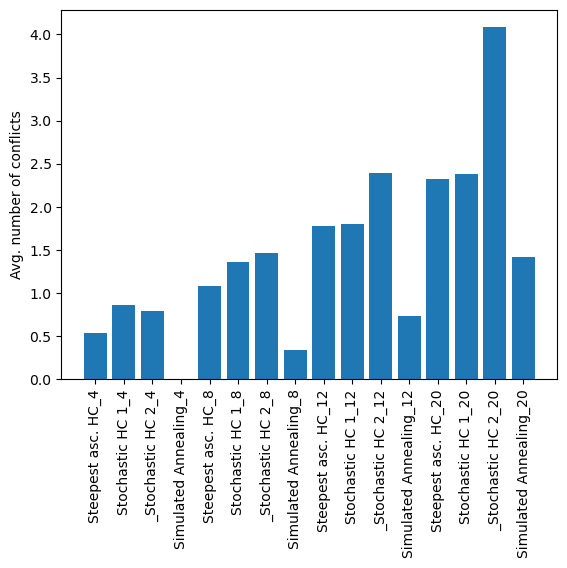

```python
# Create the labels for each bar
labels = ['Steepest asc. HC_4', 'Stochastic HC 1_4', '_Stochastic HC 2_4', 'Simulated Annealing_4',
          'Steepest asc. HC_8', 'Stochastic HC 1_8', '_Stochastic HC 2_8', 'Simulated Annealing_8',
          'Steepest asc. HC_12', 'Stochastic HC 1_12', '_Stochastic HC 2_12', 'Simulated Annealing_12',
          'Steepest asc. HC_20', 'Stochastic HC 1_20', '_Stochastic HC 2_20', 'Simulated Annealing_20',
]

# Plot the bar chart
plt.bar(labels,df['Avg. number of conflicts'])
plt.ylabel("Avg. number of conflicts")
plt.xticks(rotation=90)
plt.show()
```

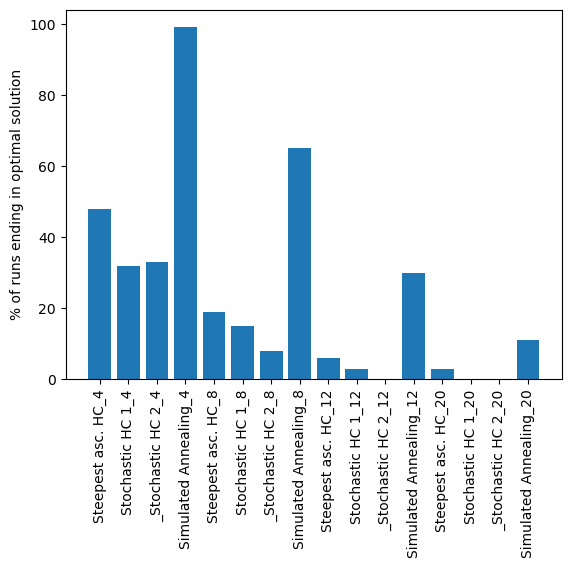

```python
# Create the labels for each bar
labels = ['Steepest asc. HC_4', 'Stochastic HC 1_4', '_Stochastic HC 2_4', 'Simulated Annealing_4',
          'Steepest asc. HC_8', 'Stochastic HC 1_8', '_Stochastic HC 2_8', 'Simulated Annealing_8',
          'Steepest asc. HC_12', 'Stochastic HC 1_12', '_Stochastic HC 2_12', 'Simulated Annealing_12',
          'Steepest asc. HC_20', 'Stochastic HC 1_20', '_Stochastic HC 2_20', 'Simulated Annealing_20',
]

# Plot the bar chart
plt.bar(labels,df['% of runs ending in optimal solution'])
plt.ylabel("% of runs ending in optimal solution")
plt.xticks(rotation=90)
plt.show()
```

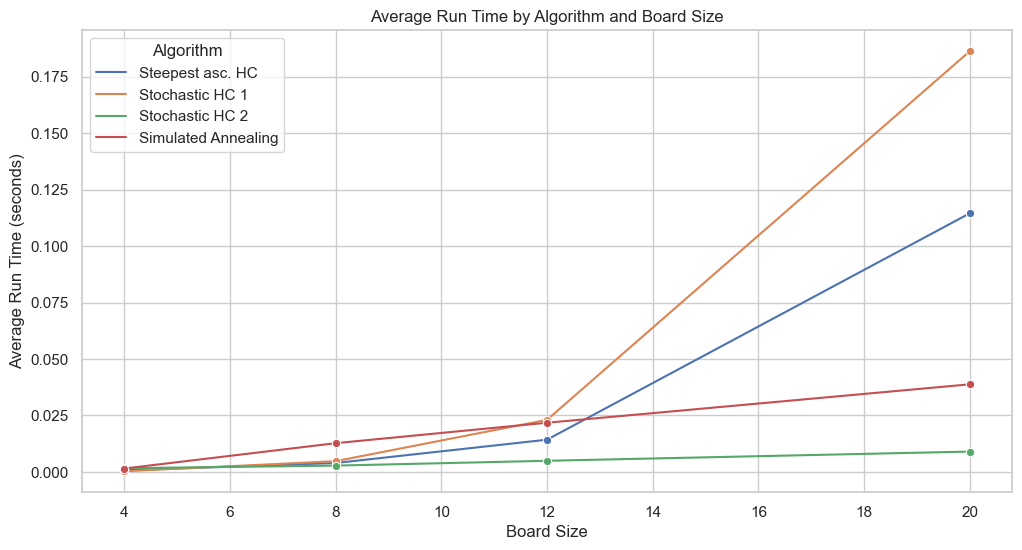

```python
import seaborn as sns

# Set the style of the visualization
sns.set(style="whitegrid")

# Create a line plot for average run time
plt.figure(figsize=(12, 6))
sns.lineplot(data=df, x='Board size', y='Avg. Run time', hue='Algorithm', marker='o')
plt.title('Average Run Time by Algorithm and Board Size')
plt.xlabel('Board Size')
plt.ylabel('Average Run Time (seconds)')
plt.legend(title='Algorithm')
plt.show()
```

How do the algorithms scale with problem size?